# Density plots of one sample t test statistic

Benedict Kongyir

09/14/2024

## 0.1 One sample case

```r
rm(list = ls())
setwd("/Users/benedictkongyir/Desktop/OSU/Research/Pretest-Simulation/Simulation/PLOT OF TEST STAT UNDER H0")
load("/Users/benedictkongyir/Desktop/OSU/Research/Pretest-Simulation/Simulation/PLOT OF TEST STAT UNDER H0/one_samples_plots.RData")
set.seed(12345)
```

### 0.1.1 Combine Plots

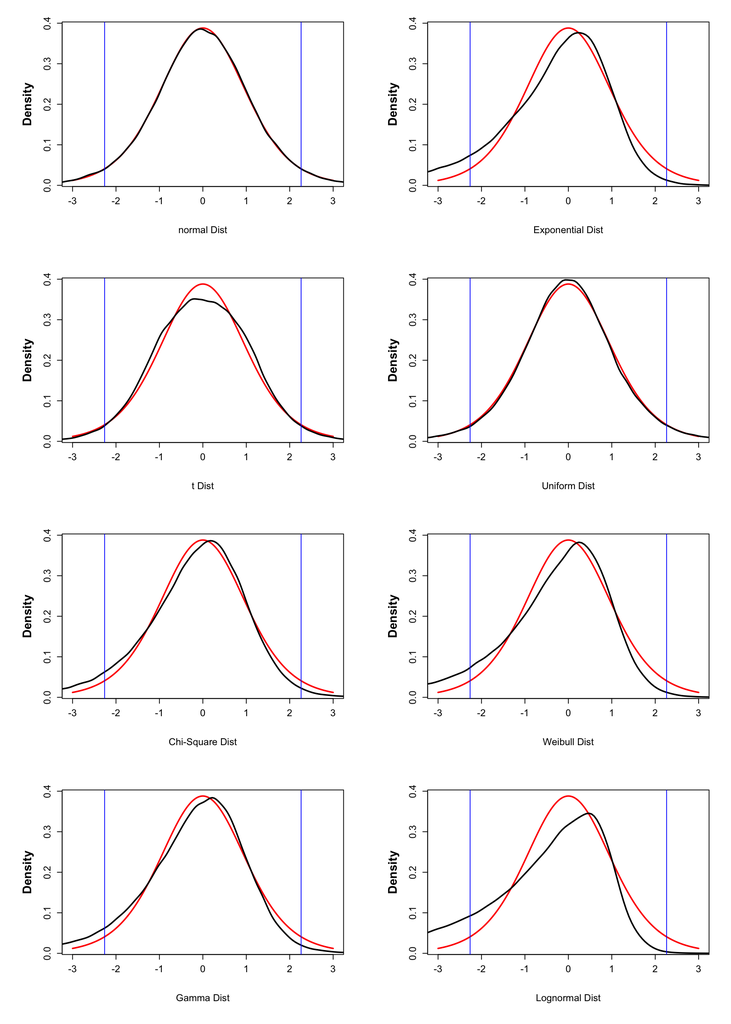

```r
# Set up a 4x2 grid layout
par(mfrow = c(4, 2))

# Adjust margins for plots and the area for the shared legend
par(mai = c(0.95, 0.85, 0.3, 0.3))  # Adjust margins as needed
par(cex.lab = 1.5, font.lab = 2, cex.axis = 1.2, cex.main = 1.5, cex.sub = 1.2)  # Customize text size

df <- n - 1  # degrees of freedom for t-distribution
z <- seq(from = -3, to = 3, by = 0.01)  # range for t-distribution

# Plot 1: Normal Distribution
plot(z, dt(z, df = df), col = "red", type = "l", lwd = 2, main = " ", sub = "normal Dist", xlab = " ", ylab = "Density")
lines(density(norm_statistic), lwd = 2)
abline(v = qt(0.025, df = df), col = "blue")
abline(v = qt(0.975, df = df), col = "blue")

# Plot 2: Exponential Distribution
plot(z, dt(z, df = df), col = "red", type = "l", lwd = 2, main = " ", sub = "Exponential Dist", xlab = " ", ylab = "Density")
lines(density(e_statistic), lwd = 2)
abline(v = qt(0.025, df = df), col = "blue")
abline(v = qt(0.975, df = df), col = "blue")

# Plot 3: t Distribution
plot(z, dt(z, df = df), col = "red", type = "l", lwd = 2, main = " ", sub = "t Dist", xlab = " ", ylab = "Density")
lines(density(t_statistic), lwd = 2)
abline(v = qt(0.025, df = df), col = "blue")
abline(v = qt(0.975, df = df), col = "blue")

# Plot 4: Uniform Distribution
plot(z, dt(z, df = df), col = "red", type = "l", lwd = 2, main = " ", sub = "Uniform Dist", xlab = " ", ylab = "Density")
lines(density(u_statistic), lwd = 2)
abline(v = qt(0.025, df = df), col = "blue")
abline(v = qt(0.975, df = df), col = "blue")

# Plot 5: Chi-Squared Distribution
plot(z, dt(z, df = df), col = "red", type = "l", lwd = 2, main = " ", sub = "Chi-Square Dist", xlab = " ", ylab = "Density")
lines(density(k_statistic), lwd = 2)
abline(v = qt(0.025, df = df), col = "blue")
abline(v = qt(0.975, df = df), col = "blue")

# Plot 6: Weibull Distribution
plot(z, dt(z, df = df), col = "red", type = "l", lwd = 2, main = " ", sub = "Weibull Dist", xlab = " ", ylab = "Density")
lines(density(w_statistic), lwd = 2)
abline(v = qt(0.025, df = df), col = "blue")
abline(v = qt(0.975, df = df), col = "blue")

# Plot 7: Gamma Distribution
plot(z, dt(z, df = df), col = "red", type = "l", lwd = 2, main = " ", sub = "Gamma Dist", xlab = " ", ylab = "Density")
lines(density(g_statistic), lwd = 2)
abline(v = qt(0.025, df = df), col = "blue")
abline(v = qt(0.975, df = df), col = "blue")

# Plot 8: Lognormal Distribution
plot(z, dt(z, df = df), col = "red", type = "l", lwd = 2, main = " ", sub = "Lognormal Dist", xlab = " ", ylab = "Density")
lines(density(log_statistic), lwd = 2)
abline(v = qt(0.025, df = df), col = "blue")
abline(v = qt(0.975, df = df), col = "blue")

# Add a shared legend outside the grid
par(fig = c(0, 1, 0, 1), mai = c(2, 2, 2, 2), mar = c(0, 0, 0, 0), new = TRUE)
plot(0, 0, type = "n", axes = FALSE, xlab = "", ylab = "")
legend("bottom", legend = c("theoretical", "empirical"), col = c("red", "black"), lty = 1, lwd = 2, cex = 1.5, ncol = 2, xpd = TRUE, bty = "n", inset = c(0, -0.15))
```

### 0.1.2 normal Distribution

The distribution of the t test statistic for samples taken from a normal distribution approximately follows the t distribution as show in the plot below. This supports the controlled Type I error rate shown in the table above.

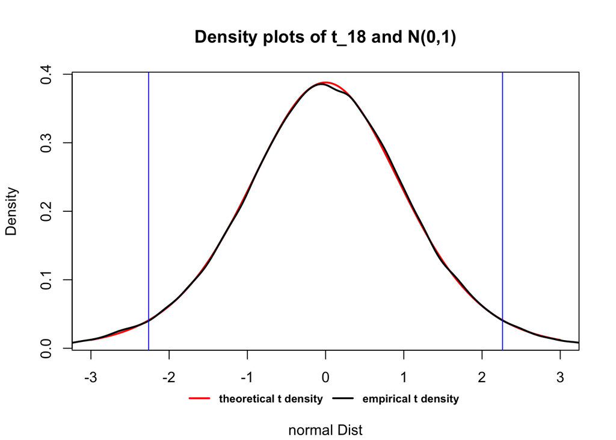

```r
df = n - 1
z <- seq(from = -3, to = 3, by = 0.01)
# normal Distribution
plot(z, dt(z, df = df), col = "red", type = "l", xlab = " ",  ylab = "Density",  lwd = 2, main = " ", sub = " ")
title(main = "Density plots of t_18 and N(0,1)", sub = "normal Dist")
lines(density(norm_statistic), lwd = 2)
abline(v=qt(0.025, df = df), col = "blue")
abline(v=qt(0.975, df = df), col = "blue")
legend("bottom", legend = c("theoretical t density", "empirical t density"), col = c("red", "black"), lty = 1, cex = 0.75, text.font = 2, lwd = 2, bty = "n", ncol=2, inset=c(0, -.22), xpd=TRUE)
```

### 0.1.3 Exponential Distribution

The distribution of the t test statistic for samples taken from exponential distribution deviates from the t distribution. It has a fatter tail to the left and slimmer tail to the right as show in the plot below. This supports the inflated Type I error rate shown in the table above.

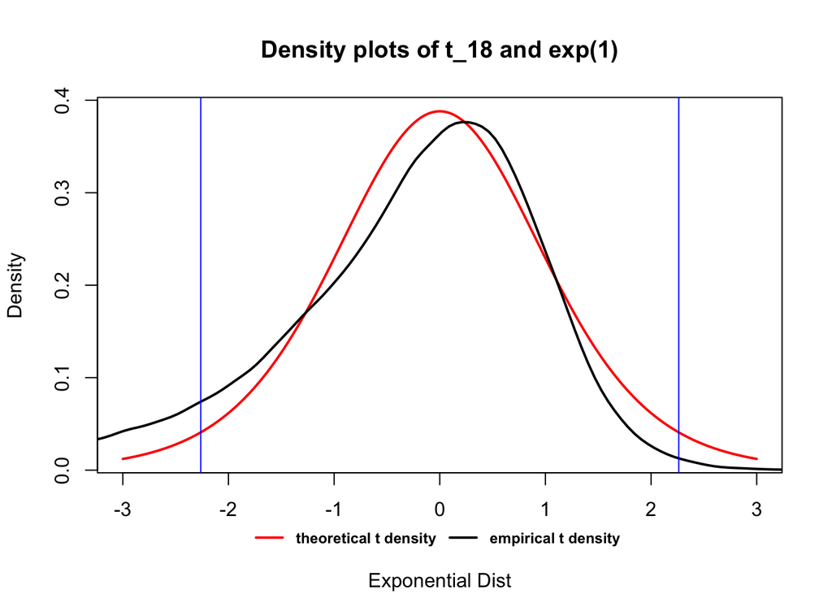

```r
# Exponential Distribution
plot(z, dt(z, df = df), col = "red",type = "l", lwd = 2, main = " ", sub = " " , xlab = " ",  ylab = "Density")
title(main = "Density plots of t_18 and exp(1)", sub = "Exponential Dist")
lines(density(e_statistic) , lwd = 2)
abline(v=qt(0.025, df = df), col = "blue")
abline(v=qt(0.975, df = df), col = "blue")
legend("bottom", legend = c("theoretical t density", "empirical t density"), col = c("red", "black"), lty = 1, cex = 0.75, text.font = 2, lwd = 2, bty = "n", ncol=2, inset=c(0, -.22), xpd=TRUE)
```

### 0.1.4 t Distribution

The distribution of the t test statistic for samples taken from t distribution is approximately follows the t distribution except that it has a flatter top. The tails are similar to that of the t distribution as show in the plot below. This supports the controlled Type I error rate shown in the table above.

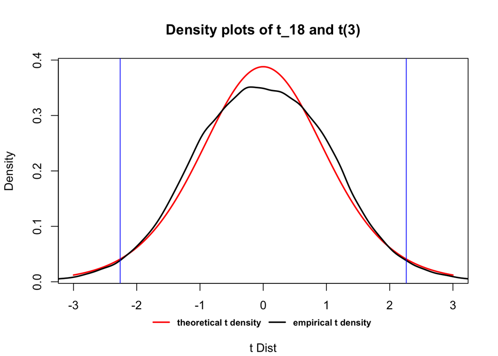

```r
# t Distribution
plot(z, dt(z, df = df), col = "red", type = "l", lwd = 2, main = " ", sub = " " , xlab = " ",  ylab = "Density")
title(main = "Density plots of t_18 and t(3)", sub = "t Dist")
lines(density(t_statistic) , lwd = 2)
abline(v=qt(0.025, df = df), col = "blue")
abline(v=qt(0.975, df = df), col = "blue")
legend("bottom", legend = c("theoretical t density", "empirical t density"), col = c("red", "black"), lty = 1, cex = 0.75, text.font = 2, lwd = 2, bty = "n", ncol=2, inset=c(0, -.22), xpd=TRUE)
```

### 0.1.5 Uniform Distribution

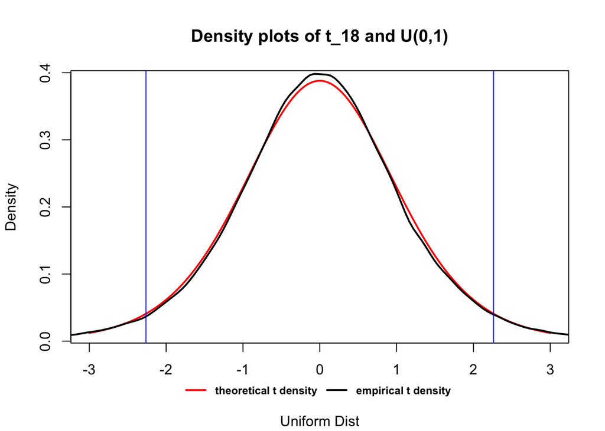

```r
# uniform Distribution
plot(z, dt(z, df = df), col = "red",  type = "l", lwd = 2, main = " ", sub = " " , xlab = " ",  ylab = "Density")
title(main = "Density plots of t_18 and U(0,1)", sub = "Uniform Dist")
lines(density(u_statistic) , lwd = 2)
abline(v=qt(0.025, df = df), col = "blue")
abline(v=qt(0.975, df = df), col = "blue")
legend("bottom", legend = c("theoretical t density", "empirical t density"), col = c("red", "black"), lty = 1, cex = 0.75, text.font = 2, lwd = 2, bty = "n", ncol=2, inset=c(0, -.22), xpd=TRUE)
```

### 0.1.6 chi-squared Distribution

The distribution of the t test statistic for samples taken from Chi-Squared distribution deviates from the t distribution. It has a fatter tail to the left and slimmer tail to the right as show in the plot below. This supports the inflated Type I error rate shown in the table above.

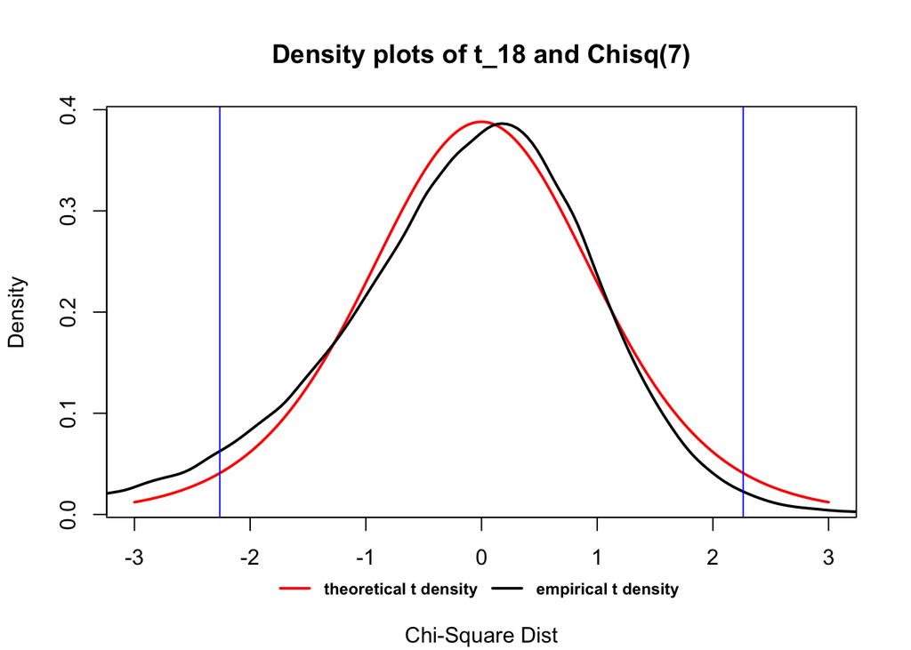

```r
# chi-squared Distribution
plot(z, dt(z, df = df), col = "red",  type = "l", lwd = 2, main = " ", sub = " " , xlab = " ",  ylab = "Density")
title(main = "Density plots of t_18 and Chisq(7)", sub = "Chi-Square Dist")
lines(density(k_statistic) , lwd = 2)
abline(v=qt(0.025, df = df), col = "blue")
abline(v=qt(0.975, df = df ), col = "blue")
legend("bottom", legend = c("theoretical t density", "empirical t density"), col = c("red", "black"), lty = 1, cex = 0.75, text.font = 2, lwd = 2, bty = "n", ncol=2, inset=c(0, -.22), xpd=TRUE)
```

### 0.1.7 Weibull Distribution

The distribution of the t test statistic for samples taken from Weibull distribution deviates from the t distribution. It has a fatter tail to the left and slimmer tail to the right as show in the plot below.This supports the inflated Type I error rate shown in the table above.

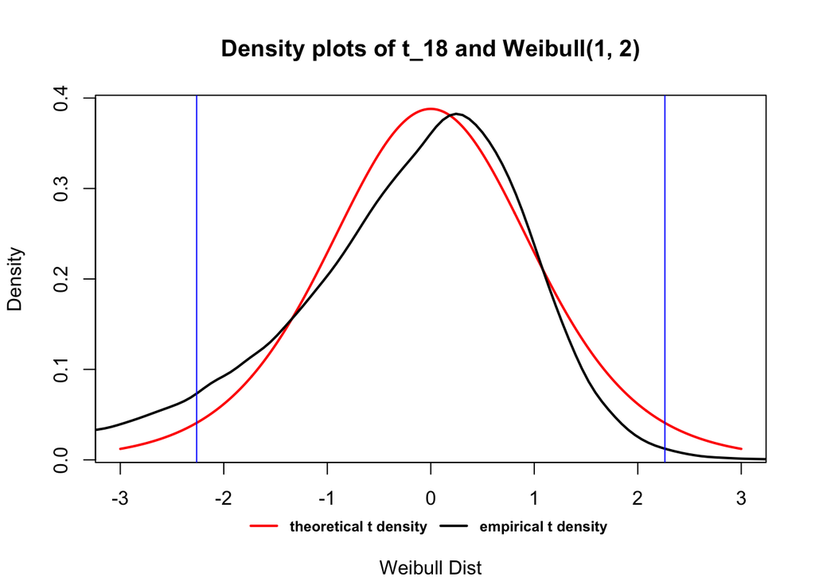

```r
# weibull Distribution
plot(z, dt(z, df = df), col = "red" , type = "l", lwd = 2, main = " ", sub = " " , xlab = " ",  ylab = "Density")
title(main = "Density plots of t_18 and Weibull(1, 2)", sub = "Weibull Dist")
lines(density(w_statistic) , lwd = 2)
abline(v=qt(0.025, df = df ), col = "blue")
abline(v=qt(0.975, df = df ), col = "blue")
legend("bottom", legend = c("theoretical t density", "empirical t density"), col = c("red", "black"), lty = 1, cex = 0.75, text.font = 2, lwd = 2, bty = "n", ncol=2, inset=c(0, -.22), xpd=TRUE)
```

### 0.1.8 Gamma Distribution

The distribution of the t test statistic for samples taken from Gamma distribution deviates from the t distribution. It has a fatter tail to the left and slimmer tail to the right as show in the plot below. This supports the inflated Type I error rate shown in the table above.

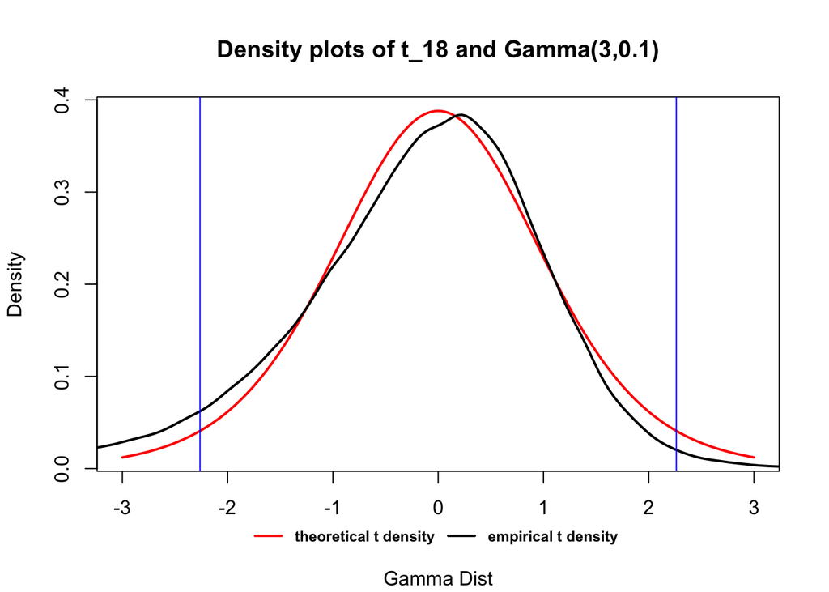

```r
# gamma Distribution
plot(z, dt(z, df = df), col = "red" , type = "l", lwd = 2, main = " ", sub = " " , xlab = " ",  ylab = "Density")
title(main = "Density plots of t_18 and Gamma(3,0.1)", sub = "Gamma Dist")
lines(density(g_statistic) , lwd = 2)
abline(v=qt(0.025, df = df), col = "blue")
abline(v=qt(0.975, df = df), col = "blue")
legend("bottom", legend = c("theoretical t density", "empirical t density"), col = c("red", "black"), lty = 1, cex = 0.75, text.font = 2, lwd = 2, bty = "n", ncol=2, inset=c(0, -.22), xpd=TRUE)
```

### 0.1.9 Lognormal Distribution

The distribution of the t test statistic for samples taken from Log normal distribution deviates much from the t distribution. It has a fatter tail to the left and slimmer tail to the right as show in the plot below. This explains why we have extreme inflation of Type I error rate for the one-sample t test for lognormal samples.

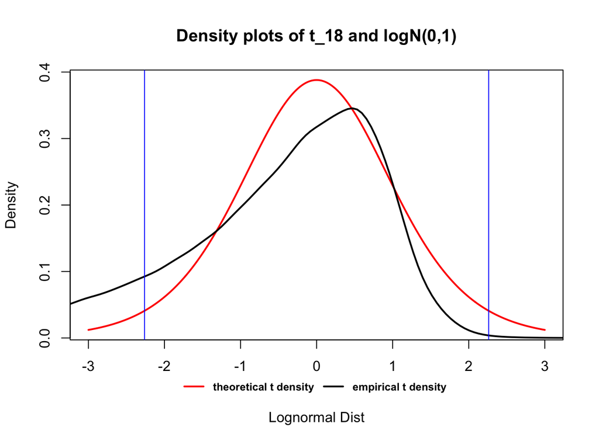

```r
# lognormal Distribution
plot(z, dt(z, df = df), col = "red" , type = "l", lwd = 2, main = " ", sub = " " , xlab = " ",  ylab = "Density")
title(main = "Density plots of t_18 and logN(0,1)", sub = "Lognormal Dist")
lines(density(log_statistic), lwd = 2)
abline(v=qt(0.025, df = df), col = "blue")
abline(v=qt(0.975, df = df), col = "blue")
legend("bottom", legend = c("theoretical t density", "empirical t density"), col = c("red", "black"), lty = 1, cex = 0.75, text.font = 2, lwd = 2, bty = "n", ncol=2, inset=c(0, -.22), xpd=TRUE)
```

### 0.1.10 Estimated Type I errors

```r
# power of SW test
errors <-c( Type1_error_norm, Type1_error_e, Type1_error_t, Type1_error_u,Type1_error_k,Type1_error_w, Type1_error_g,Type1_error_l)
dist <-c("normal", "exponential", "t", "uniform", "chi-squared", "weillbul", "gamma", "lognormal")

# put data in a table
kk <- data.frame(dist, errors)
knitr::kable(kk, caption = "Estimated Type I errors")
```

Estimated Type I errors

| dist | errors |
| --- | --- |
| normal | 0.04992 |
| exponential | 0.09853 |
| t | 0.03901 |
| uniform | 0.05369 |
| chi-squared | 0.06451 |
| weillbul | 0.09844 |
| gamma | 0.06776 |
| lognormal | 0.16088 |